# Reproducible Research

Denford Madenyika

December 22, 2016

## Here we are going to global options and load libraries needed for this assignment

```r
library(lattice)
library(knitr)
opts_chunk$set(echo=TRUE,results="show",cache=TRUE)
setwd('C:/Users/denfordm/Desktop/Coursera/RResearch')
```

I will first load the data

Process/transform the data (if necessary) into a format suitable for your analysis

```r
dfMaster <- read.table("activity.csv",
               header=TRUE,
               sep=",",
               stringsAsFactors = FALSE,
               colClasses = c("numeric","Date","numeric")
               )
```

```r
df <- dfMaster
```

Find the total number of steps taken per day

Generate a histogram to show number of steps taken per day

Find the mean and median of the total number of steps taken per day

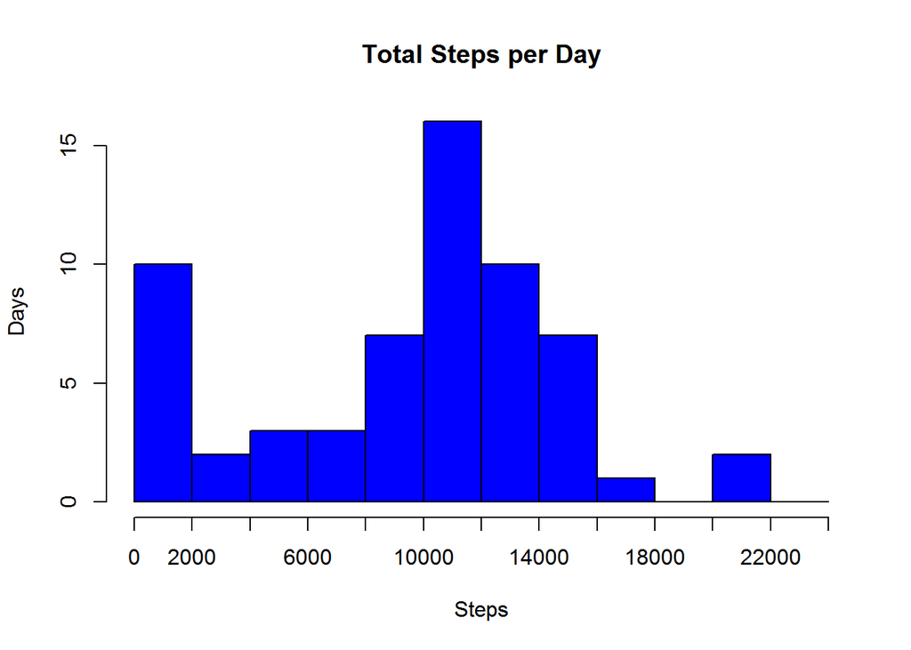

```r
TotalStepsByDay <- aggregate(df$steps,list(date=df$date),sum,na.rm=TRUE)
xAxisBreakdown = seq(from=0,to=25000,by=2000)
hist(TotalStepsByDay$x,
      breaks = xAxisBreakdown,
      main="Total Steps per Day",
      col="blue",
      xlab="Steps",
      ylab="Days",
      xaxt="n")
axis(side=1,at=xAxisBreakdown,labels=xAxisBreakdown)
```

Calculate the mean

```r
stepMean <- mean(TotalStepsByDay$x,na.rm=T)
print(paste("The Mean number of steps per day is",round(stepMean,1)))
```

```
## [1] "The Mean number of steps per day is 9354.2"
```

Calculate the median

```r
stepMedian <- median(TotalStepsByDay$x,na.rm=T)
print(paste("The Median number of steps per day is",round(stepMedian,1)))
```

```
## [1] "The Median number of steps per day is 10395"
```

Calculate the average daily activity pattern through the time series function

I am interested in the hours

```r
intHours <- df$interval %/% 100
```

I am only interested in the 24 hour format, two digit hours

```r
intHours <- ifelse(intHours < 10,paste("0",intHours,sep=""),intHours)
```

Here I am interested in the minutes

```r
intMinutes <- df$interval %% 100
```

I also just want two digit minutes

```r
intMinutes <- ifelse(intMinutes < 10,paste("0",intMinutes,sep=""),intMinutes)
```

I concatenate minutes and hours and convert to a time with strptime()

```r
intTime <- paste(intHours,":",intMinutes,sep="")
intTime <- strptime(intTime,format="%H:%M")
```

Then I add time variable into the data set

```r
df <- cbind(df,intTime)
```

This gives me the time function I use it to compute number of steps

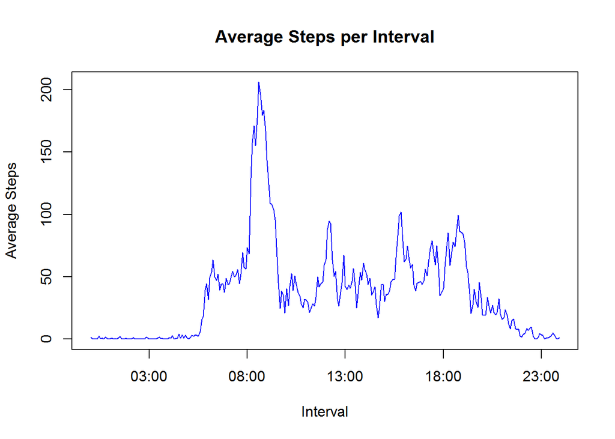

```r
SPI <- aggregate(df$steps,list(intTime=df$intTime),mean,na.rm=TRUE)
plot(SPI$intTime,SPI$x,
     type = "l",
     col = "blue",
     main = "Average Steps per Interval",
     xlab = "Interval",
     ylab = "Average Steps")
```

I am also interested in the interval with highest interval

```r
MaxStepAvg <- max(SPI$x)
IntervalWithMaxStepAvg <- SPI$intTime[SPI$x == MaxStepAvg]
```

Here I will handle missing values

```r
countNAs <- sum(is.na(df$steps))
```

Average Interval Steps

```r
names(SPI)[names(SPI)=="x"] <- "avgIntervalSteps"
```

average by intTime

```r
dfWithAvg <- merge(x=df,y=SPI,by="intTime",all.x=TRUE)
```

Use steps, if available, else avgIntervalSteps.

```r
dfWithAvg$imputedSteps <- ifelse(is.na(dfWithAvg$steps),
                                 dfWithAvg$avgIntervalSteps,
                                 dfWithAvg$steps)
```

Average

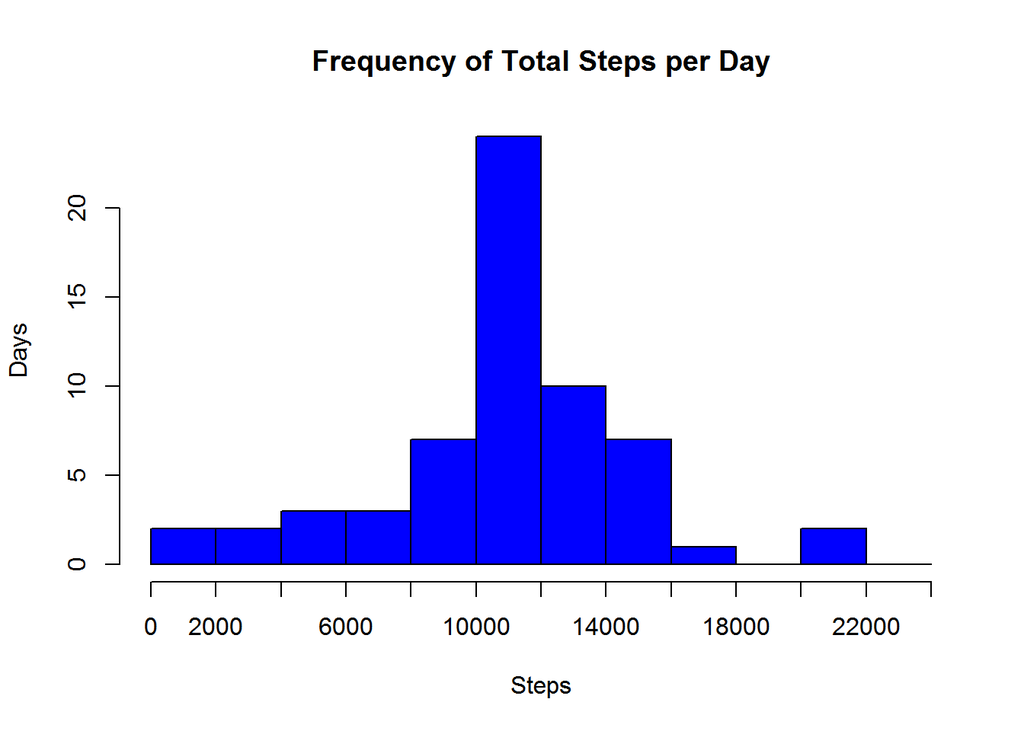

```r
TotalStepsByDayImputed <- aggregate(dfWithAvg$imputedSteps,list(date=dfWithAvg$date),sum,na.rm=TRUE)
xAxisBreakdown = seq(from=0,to=25000,by=2000)
hist(TotalStepsByDayImputed$x,
      breaks = xAxisBreakdown,
      main="Frequency of Total Steps per Day",
      col="blue",
      xlab="Steps",
      ylab="Days",
      xaxt="n")
axis(side=1,at=xAxisBreakdown,labels=xAxisBreakdown)
```

Mean of imputed steps

```r
stepMeanImputed <- mean(TotalStepsByDayImputed$x,na.rm=T)
print(paste("Mean number of imputed steps per day is",round(stepMeanImputed,1)))
```

```
## [1] "Mean number of imputed steps per day is 10766.2"
```

Median number of imputed steps

```r
stepMedianImputed <- median(TotalStepsByDayImputed$x,na.rm=T)
print(paste("Median number of imputed steps per day is",round(stepMedianImputed,1)))
```

```
## [1] "Median number of imputed steps per day is 10766.2"
```

Weekdays averages Weekend averages I will compute and compare the averages

```r
dfWithAvg$weekday <- weekdays(dfWithAvg$date)
dfWithAvg$weekendFlag <- ifelse(dfWithAvg$weekday=="Saturday" | dfWithAvg$weekday=="Sunday","Weekend","Weekday")
```

Average steps per day for weekend and weekdays

```r
SPI2 <- aggregate(dfWithAvg$imputedSteps,list(intTime=dfWithAvg$intTime,weekendFlag=dfWithAvg$weekendFlag),mean,na.rm=TRUE)
```

Set up a sequence

```r
xn <- seq(min(dfWithAvg$intTime),max(dfWithAvg$intTime),by="4 hour")
```

24 hour format

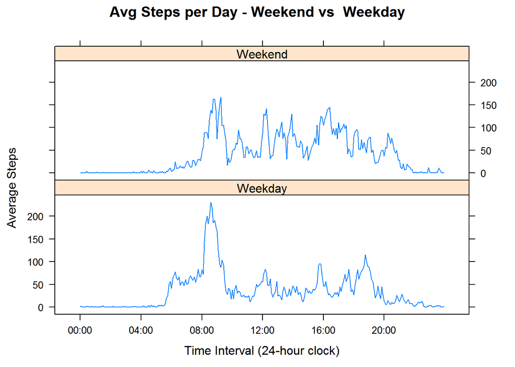

```r
xyplot(x~intTime|weekendFlag,
  data=SPI2,
  type="l",
  layout=c(1,2),
  xlab = "Time Interval (24-hour clock)",
  ylab = "Average Steps",
  main = "Avg Steps per Day - Weekend vs  Weekday",
       scales=list(
                  x=list(
                        at=xn,
                        labels=format(xn,"%H:%M")
                        )
                  )
        )
```